# Monte Carlo Integration for Statistical Inference

## Q1)

Suppose that you have 3 different events which are:

- that a person get at least 1 six when 6 dice are rolled,
- at least 2 sixes when 12 dice are rolled, or
- at least 3 sixes when 18 dice are rolled.

Simulate which of the three event is more likely. What are the probabilities?

**SOLUTION**

We know that probability of exactly x sixes when 6 dice are thrown is

$$\binom{6}{x} (\frac{1}{6}) (\frac{5}{6})^{5}$$
The probability of x sixes for n dice is

$$\binom{n}{x} (\frac{1}{6})^x (\frac{5}{6})^{n-x},\ x=0,1,...,n$$

This formula gives the terms of what is called a binomial distribution. The probability of 1 or more sixes with 6 dice is the complement of the probability of 0 sixes:

$$1- \binom{6}{0} (\frac{1}{6})^0 (\frac{5}{6})^{6} = 0.665$$

When 6n dice are rolled, the probability of n or more sixes is;

$$\sum_{x=n}^{6n}\binom{6n}{x} (\frac{1}{6})^x (\frac{5}{6})^{6n-x} = 1- \sum_{x=0}^{n-1}\binom{6n}{x} (\frac{1}{6})^x (\frac{5}{6})^{6n-x}$$
By using this formula, we can obtain;

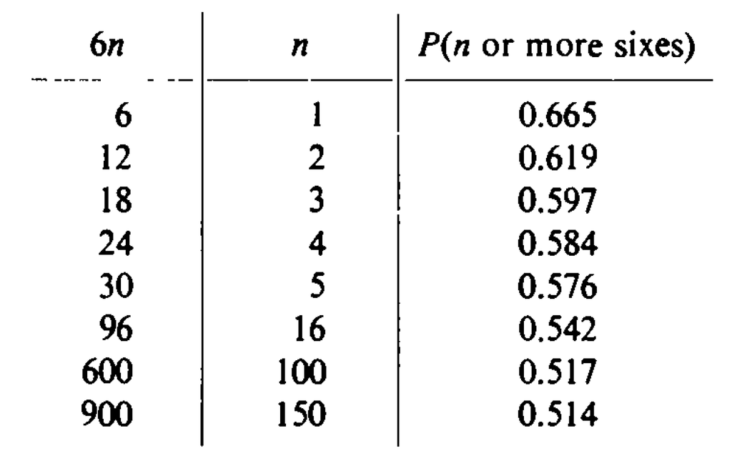

```r
set.seed(361)

dice <- function(n){

  observing_6_first_case <- c()
  observing_6_second_case <- c()
  observing_6_third_case <- c()

  for (i in 1:n){
        # throws a dice
        # We must write replace = T since the same numbers can come up every time the dice are rolled.

        dice1 <- replicate(6, sample(1:6, 1, replace = TRUE)) #in first case we have 6 dice, so replicate =6
        dice2 <- replicate(12, sample(1:6, 1, replace = TRUE)) #in second case we have 12 dice, so replicate =12
        dice3 <- replicate(18, sample(1:6, 1, replace = TRUE)) #in third case we have 18 dice, so replicate= 18

        #At least 1 six out of 6 dice
        if(length(dice1[dice1==6]) != 0){
        observing_6_first_case[i] <- 1}

        else{observing_6_first_case[i] <- 0}

        #At least 2 six out of 12 dice

        if(length(dice2[dice2==6]) != 0 & length(dice2[dice2==6]) != 1){
        observing_6_second_case[i] <- 1}

        else{observing_6_second_case[i] <- 0}


        #At least 3 six out of 18 dice

        if(length(dice3[dice3==6]) != 0 & length(dice3[dice3==6]) != 1 & length(dice3[dice3==6]) != 2){
        observing_6_third_case[i] <- 1}

        else{observing_6_third_case[i] <- 0}


        }


prob_for_first_case = (sum(observing_6_first_case)/n)
prob_for_second_case = (sum(observing_6_second_case)/n)
prob_for_third_case = (sum(observing_6_third_case)/n)

cat("Probability of getting at least 1 six when 6 dice are rolled", prob_for_first_case, "\n",
    "Probability of getting at least 2 six when 12 dice are rolled", prob_for_second_case, "\n",
    "Probability of getting at least 3 six when 18 dice are rolled", prob_for_third_case)
}

dice(100)
```

```
## Probability of getting at least 1 six when 6 dice are rolled 0.64
##  Probability of getting at least 2 six when 12 dice are rolled 0.59
##  Probability of getting at least 3 six when 18 dice are rolled 0.56
```

## Q2)

In a chemical plant, various fluid products are derived from a raw material (fluid) which consists of a set of compound substances. In order to minimize corrosion in the equipment, Caustic soda is used. If 8 caustic soda is used, pH and iron value of the raw material remains at the desired level. If the desired level of pH and iron are not reached, product derivation should be stopped. Suppose that the average amount caustic soda in a particular sample of 35 chemical plant is 7.91 with a variance of 0.03 squared $s^2$. Is there evidence that the product derivation should be stopped and production wait? The loss of production is potentially so great that the iron and pH values are not at the desired level that chemists consider the significance level to be 99% in the analysis. Set the Null and Alternative Hypothesis (Take M = 100000 repetitions).

$$H_0: \mu =8,\ H_1:\mu \neq 8$$

1. Simulate the hypothesis using CRITICAL VALUE APPROACH.

$$Z= \frac{\bar x - \mu}{\sigma / \sqrt n}$$

1. For this set of data: z= (8 – 7.91) / (√0.03/√35) = 3.07 –> **test value**
2. Find the rejection region area (given by your alpha level above) from the z-table. An area of .01 is equal to a z-score of -2.6 and 2.6 (since it is two sided test) –> **critical value**

critical values are :

[figure not shown]

3. If the test value is between critical values, we fail to reject the null hypothesis. If it’s not between, we can reject the null hypothesis. In this case, it is not between critical values, so we can reject the null hypothesis.

```
## From MC Simulation we get an estimated Critical Value of 2.567 and -2.566
##  Since Test Statistic is 3.074
##  which is not between critical values, namely test statistics is in rejection region,
##  we have enough evidence to reject the null hypothesis
##
```

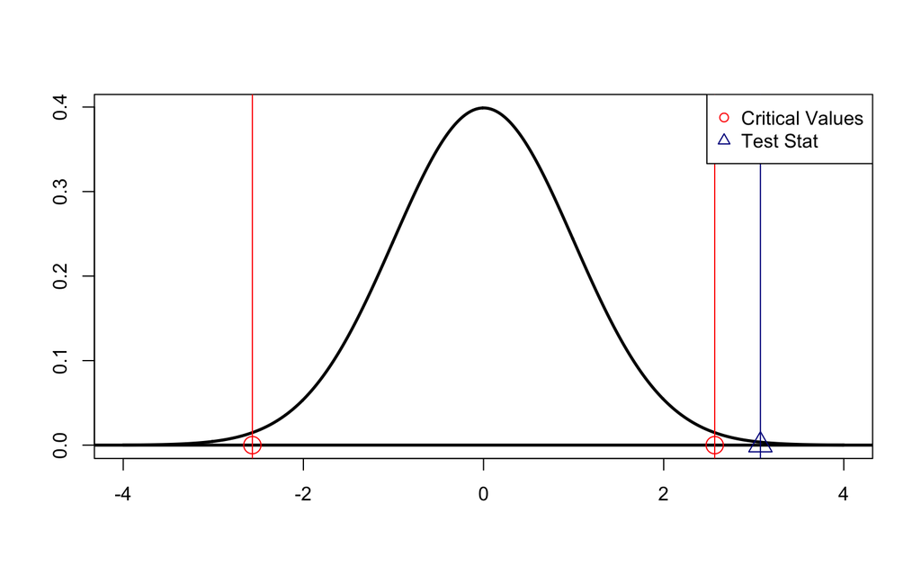

```
## $test_stat
## [1] 3.074085
##
## $Critical_Value_upper
## [1] 2.566535
##
## $Critical_Value_lower
## [1] -2.566422
```

```r
cv <- function(n,xbar, Mu0, sigma, M, alpha){

  S.Error <- (sigma / sqrt(n))
  test.stat <- (xbar - Mu0) / S.Error

  TestScores <- numeric(M)

  for(i in 1:M){
    x <- rnorm(n, Mu0, sigma) # generate random sample under H0
    TestScores[i] <- (mean(x) - Mu0) / S.Error
  }
  # Get the critical value for alpha
  Critical.Value_lower <- quantile(TestScores, alpha/2)
  Critical.Value_upper <- quantile(TestScores,1-(alpha/2))

  if(abs(test.stat) > abs(Critical.Value_lower) & abs(test.stat) < abs(Critical.Value_upper)){
    cat("From MC Simulation we get an estimated Critical Value of",
        round(Critical.Value_upper,3),"and", round(Critical.Value_lower,3)  ,"\n", "Since Test Statistic is",
        round(test.stat,3),"\n", "which is between critical values, namely acceptence region" ,"\n",
        "we do not have enough evidence to reject the null hypothesis",
        "\n","\n")
  }else{
     cat("From MC Simulation we get an estimated Critical Value of",
        round(Critical.Value_upper,3),"and", round(Critical.Value_lower,3)  ,"\n", "Since Test Statistic is",
        round(test.stat,3),"\n", "which is not between critical values, namely test statistics is in rejection region,"
        ,"\n","we have enough evidence to reject the null hypothesis",
        "\n","\n")
  }

a <- seq(-4,4,0.01)
  plot(a, dnorm(a), type = "l",lwd = 2.5, ylab = "", xlab = "")
  abline(h=0, lwd = 2.5)
  abline(v = Critical.Value_upper, col = "Red")
  abline(v = Critical.Value_lower, col = "Red")
  abline(v = test.stat, col = "Dark Blue")
  points(x = Critical.Value_upper, y = 0, pch = 1, cex = 2, col = "Red")
   points(x = Critical.Value_lower, y = 0, pch = 1, cex = 2, col = "Red")
  points(x = test.stat, y = 0, pch = 2, cex = 2, col = "Dark Blue")
  legend("topright",legend = c("Critical Values","Test Stat"),
         col = c("Red","Dark Blue"), pch = 1:2)

  return(list(test_stat = test.stat,
              Critical_Value_upper = as.numeric(Critical.Value_upper),
               Critical_Value_lower = as.numeric(Critical.Value_lower)))
}

M <- 10^5
n <- 35
alpha <- 0.01
Mu0 <- 7.91
xbar <- 8
sigma <- sqrt(0.03)

cv(n, xbar, Mu0, sigma,  M, alpha)
```

2. Simulate the hypothesis using P-VALUE APPROACH.

```r
pvalue <- function(n, xbar, Mu0, sigma, M, alpha){

  S.Error <- (sigma / sqrt(n))
  test.stat <- (xbar - Mu0) / S.Error

  TestScores <- numeric(M)

  for(i in 1:M){
    x <- rnorm(n, Mu0, sigma) # generate random sample under H0
    TestScores[i] <- (mean(x) - Mu0) / S.Error
  }

  pvalue <- 2*length(which(TestScores >= abs(test.stat))) / M

  if(pvalue < alpha){
    cat("Since P-value",pvalue,"which is less than the significance level", alpha, "\n",
        "Therefore, we can reject the null hypothesis.","\n","\n")
  }else{
    cat("Since P-value",pvalue,
        "which is greater than the significance level", alpha, "\n",
        "Therefore, we can not reject the null hypothesis.",
        "\n","\n")
  }
  return(list(P_Value = pvalue)) #return to p-value
}

M <- 10^5
n <- 35
alpha <- 0.01
Mu0 <- 8
xbar <- 7.91
sigma <- sqrt(0.03)

pvalue(n, xbar, Mu0, sigma, M, alpha)
```

```
## Since P-value 0.00202 which is less than the significance level 0.01
##  Therefore, we can reject the null hypothesis.
##
```

```
## $P_Value
## [1] 0.00202
```

3. Construct a 95% confidence interval for the mean. Use a Monte Carlo method to obtain an empirical estimate of the confidence level. (Take M = 100000 repetitions )

Use the formula;

$$CI = P(\bar{X}-Z_{1-\alpha/2}\frac{S}{\sqrt{n}} \le \mu \le \bar{X}+Z_{1-\alpha/2})\frac{S}{\sqrt{n}}$$

```r
CL <- function(n, M, alpha){
  # we are assuming that the population has a normal shape
  mu <- 7.91
  sigma <- sqrt(0.03)

  matrix <- matrix(0, nrow = M, ncol = 2, dimnames = list(c(1:M), c("Lower","Upper")))

  for(i in 1:M){
    x <- rnorm(n,mu,sigma)
    x_bar <- mean(x)
    x_sd <- sd(x)
    matrix[i,1] <- x_bar - qnorm(1-alpha/2) * (x_sd/sqrt(n))
    matrix[i,2] <- x_bar + qnorm(1-alpha/2) * (x_sd/sqrt(n))
    }
  out <- list(CI = apply(matrix,2,mean), conf_level = 1-alpha) #mean of rows
  return(out)
}

M <- 10^5
alpha <- 0.05
n <- 100

CL(n, M, alpha)
```

```
## $CI
##    Lower    Upper
## 7.876092 7.943827
##
## $conf_level
## [1] 0.95
```

## Q3)

$1^{st}$ population

$$X \sim Normal(\mu=1.5,\ \sigma=0.07)$$

$2^{nd}$ population

$$Y \sim Cauchy(location=0,\ scale=0.5)$$

(HINT: you can generate samples from rnorm(n, mu, sigma) and rcauchy(n, location, scale))

**a)** Please write a **function** to find out which test has the highest power and at what sample size (Take the size of Monte Carlo; M = 100000 repetitions). According to the power results which test is more appropriate for these samples and what can be the reason for it? You can plot the power curve (extra 5 pt).

$$H_0: \mu_x = \mu_y;\ H_1: \mu_x \neq \mu_y$$

| test | sample_size | power |
| --- | --- | --- |
| Two-sample t-test(var.equal=TRUE) | 10 | 0.537 |
| Two-sample t-test(var.equal=TRUE) | 20 | 0.521 |
| Two-sample t-test(var.equal=TRUE) | 50 | 0.516 |
| Two-sample t-test(var.equal=TRUE) | 100 | 0.532 |
| Two-sample t-test(var.equal=FALSE) | 10 | 0.416 |
| Two-sample t-test(var.equal=FALSE) | 20 | 0.435 |
| Two-sample t-test(var.equal=FALSE) | 50 | 0.431 |
| Two-sample t-test(var.equal=FALSE) | 100 | 0.459 |
| Wilcoxon Runk Sum test | 10 | 0.642 |
| Wilcoxon Runk Sum test | 20 | 0.646 |
| Wilcoxon Runk Sum test | 50 | 0.630 |
| Wilcoxon Runk Sum test | 100 | 0.633 |

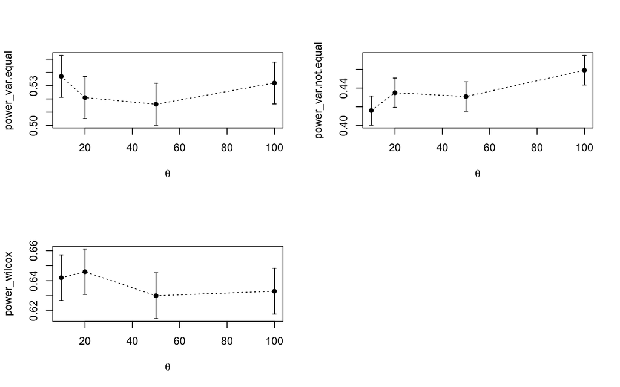

```r
set.seed(361)
power.fun<-function(mu, sigma, location, scale, n){
  m<-1000
  M<-length(n)

  power_var.equal <- numeric(M)
  power_var.not.equal <- numeric(M)
  power_wilcox <- numeric(M)

  for (i in 1:M){
    N<-n[i]
    pvalues_var.equal<-replicate(m,expr = {
      x<-rnorm(n, mu, sigma)
      y<-rcauchy(n, location = location, scale = scale)
      t.test_var.equal<- t.test(x, y, var.equal = TRUE)
      t.test_var.equal$p.value})
      power_var.equal[i] <- mean(pvalues_var.equal <= .05)

  }

  for (i in 1:M){
    N<-n[i]
    pvalues_var.not.equal <-replicate(m,expr = {
      x <-rnorm(n, mu, sigma)
      y <-rcauchy(n, location = location, scale = scale)
      t.test_var.not.equal<- t.test(x, y, var.equal = FALSE)
      t.test_var.not.equal$p.value})
      power_var.not.equal[i] <- mean(pvalues_var.not.equal <= .05)

  }

  for (i in 1:M){
    N<-n[i]
    pvalues_wilcox <- replicate(m,expr = {
      x <-rnorm(n, mu, sigma)
      y <-rcauchy(n, location = location, scale = scale)
      wilcox.test<- wilcox.test(x, y)
      wilcox.test$p.value})
      power_wilcox[i] <- mean(pvalues_wilcox <= .05)

  }


  var.equal <- data.frame(sample_size=n, power = power_var.equal)
  var.not.equal <- data.frame(sample_size=n, power = power_var.not.equal)
  wilcox <- data.frame(sample_size=n, power = power_wilcox)
  test <- rep(c("Two-sample t-test(var.equal=TRUE)","Two-sample t-test(var.equal=FALSE)","Wilcoxon Runk Sum test"),each=4)
  data<- rbind(var.equal, var.not.equal, wilcox)
  data <- cbind(test, data)


library(dplyr)
library(kableExtra)
table <- kbl(data) %>%
  kable_classic("striped", full_width = T) %>%
  row_spec(1:4, bold = T, background = "salmon") %>%
  row_spec(5:8, bold = T, background = "pink") %>%
  row_spec(9:12, bold = T, background = "lightblue")





par(mfrow=c(2,2))

library(Hmisc)

se_var.equal <- sqrt(power_var.equal * (1-power_var.equal) / m)
errbar(n, power_var.equal, yplus = power_var.equal+se_var.equal, yminus = power_var.equal-se_var.equal,
xlab = bquote(theta))
lines(n, power_var.equal, lty=3)

se_var.not.equal <- sqrt(power_var.not.equal * (1-power_var.not.equal) / m)
errbar(n, power_var.not.equal, yplus = power_var.not.equal+se_var.not.equal, yminus = power_var.not.equal-se_var.not.equal,
xlab = bquote(theta))
lines(n, power_var.not.equal, lty=3)

se_wilcox <- sqrt(power_wilcox * (1-power_wilcox) / m)
errbar(n, power_wilcox, yplus = power_wilcox + se_wilcox, yminus = power_wilcox-se_wilcox,
xlab = bquote(theta))
lines(n, power_wilcox, lty=3)

return(table)
}
power.fun(mu=1.5, sigma=0.07, location=0, scale = 0.5, c(10,20,50,100))
```

As seen that power has reached its maximum value in **Wilcoxon Runk Sum test** and **sample size n=20**. That means **Wilcoxon Runk Sum test** is more appropriate for these samples. The reasoning of is **Wilcoxon Runk Sum test** is non-parametric test. That is, no assumptions need to be provided like normality. Since our samples does not normally distributed (their distribution is cauchy), using non-parametric test is more appropriate. That is why power of this test is highest.

**b)** Please write a **function** to find out which test has the smallest Type-I error and standard error of the estimate and at what sample size (Take the size of Monte Carlo; M = 100000 repetitions). Do not forget to comment on your results.

```r
set.seed(361)

type_Ierror <- function(mu, sigma, location, scale, n, alpha){

  m<-1000
  M<-length(n)
  p.hat_var.equal <- numeric(M)
  p.hat_var.not.equal <- numeric(M)
  p.hat_wilcox <- numeric(M) #since we have 3 different tests, we create 3 different vector

  for (i in 1:M){
    N<-n[i]
    pvalues_var.equal<-replicate(m,expr = {
      x<-rnorm(n, mu, sigma)
      y<-rcauchy(n, location = location, scale = scale)

      ttest_equal.var<- t.test(x, y, var.equal = TRUE)
      ttest_equal.var$p.value})
      p.hat_var.equal[i] <- mean(pvalues_var.equal < alpha)

  }


  for (i in 1:M){
    N<-n[i]
    pvalues_var.not.equal<-replicate(m,expr = {
      x<-rnorm(n, mu, sigma)
      y<-rcauchy(n, location = location, scale = scale)

      ttest_nonequal.var<- t.test(x, y, var.equal = TRUE)
      ttest_nonequal.var$p.value})
      p.hat_var.not.equal[i] <- mean(pvalues_var.not.equal < alpha)

  }


  for (i in 1:M){
    N<-n[i]
    pvalues_wilcox<-replicate(m,expr = {
      x <-rnorm(n, mu, sigma)
      y <-rcauchy(n, location = location, scale = scale)
      wilcox.test<- wilcox.test(x, y)
      wilcox.test$p.value})
      p.hat_wilcox[i] <- mean(pvalues_wilcox < alpha)

  }


  se.hat_var.equal <- sqrt(p.hat_var.equal * (1 - p.hat_var.equal) / m)
  se.hat_var.not.equal <- sqrt(p.hat_var.not.equal * (1 - p.hat_var.not.equal) / m)
  se.hat_wilcox <- sqrt(p.hat_wilcox * (1 - p.hat_wilcox) / m)



  var.equal <- data.frame(sample_size=n, type_Ierror = p.hat_var.equal, se = se.hat_var.equal)
  var.not.equal <- data.frame(sample_size=n, type_Ierror = p.hat_var.not.equal, se = se.hat_var.not.equal)
  wilcox <- data.frame(sample_size=n, type_Ierror = p.hat_wilcox, se = se.hat_wilcox)
  test <- rep(c("Two-sample t-test(var.equal=TRUE)","Two-sample t-test(var.equal=FALSE)","Wilcoxon Runk Sum test"),each=4)
  data<- rbind(var.equal, var.not.equal, wilcox)
  data <- cbind(test, data)


library(dplyr)
library(kableExtra)
kbl(data) %>%
  kable_classic("striped", full_width = T) %>%
  row_spec(1:4, bold = T, background = "salmon") %>%
  row_spec(5:8, bold = T, background = "pink") %>%
  row_spec(9:12, bold = T, background = "lightblue")
}
type_Ierror(mu=1.5, sigma=0.07, location=0, scale = 0.5, n= c(10,20,50,100), alpha = 0.05)
```

| test | sample_size | type_Ierror | se |
| --- | --- | --- | --- |
| Two-sample t-test(var.equal=TRUE) | 10 | 0.537 | 0.0157680 |
| Two-sample t-test(var.equal=TRUE) | 20 | 0.521 | 0.0157974 |
| Two-sample t-test(var.equal=TRUE) | 50 | 0.516 | 0.0158033 |
| Two-sample t-test(var.equal=TRUE) | 100 | 0.532 | 0.0157790 |
| Two-sample t-test(var.equal=FALSE) | 10 | 0.534 | 0.0157748 |
| Two-sample t-test(var.equal=FALSE) | 20 | 0.545 | 0.0157472 |
| Two-sample t-test(var.equal=FALSE) | 50 | 0.540 | 0.0157607 |
| Two-sample t-test(var.equal=FALSE) | 100 | 0.561 | 0.0156933 |
| Wilcoxon Runk Sum test | 10 | 0.642 | 0.0151603 |
| Wilcoxon Runk Sum test | 20 | 0.646 | 0.0151223 |
| Wilcoxon Runk Sum test | 50 | 0.630 | 0.0152676 |
| Wilcoxon Runk Sum test | 100 | 0.633 | 0.0152418 |

**c)** Do Power and Type-I error lead to the same result, and what is the reasoning?

If the null hypothesis is true, but we reject this hypothesis, we make a type-I error, and this error equals alpha. If the hypothesis is wrong and we accept the hypothesis, we make a type-II error and this error equals beta. Power is also equal to 1-beta, power calculates the probability of rejecting when the hypothesis is false. We always want to have a low error rate, so we need to reduce alpha betas as much as possible. But we can’t lower alpha and beta at the same time. When lowering beta, alpha increases, and when lowering alpha, beta increases. Because of this, power and type-I error do not give same conclusion about which test is better.

## Q4)

Three apparently equally good prisoners; A, B, and C, applied for parole. The parole board has decided to release two of the three prisoners, and the prisoners know it, but not which two. Prisoner A’s guard friend knows who will be released. Prisoner A realizes that it is unethical to ask the guard if A will be released, but considers asking the name of any prisoner, other than himself to be released. He thinks he has a 2/3 chance of being released before he asks. If the guard says, “B will be released”, he thinks his chances are now down to 1/2 because he thinks A and B, or B and C will be released. In the end, A decides not to reduce his chances by asking.

Now, simulate both cases; - The probability of “A” is released after he ask the warder.

- The probability of “A” is released when he does not ask the warder.

By simulation this probability, please decide that if A is mistaken in his calculations or not.

**SOLUTION**

“A” thinks his experiment has three possible outcomes: the released pairs AB, AC, BC with equal probabilities of 1/3. From his point of view, that is the correct sample space for the experiment conducted by the parole board given that they are to release two of the three. But A’s own experiment adds an event the response of the warder.

The outcomes of his proposed experiment and reasonable probabilities for them are:

1. A and B released and warder says B, probability 1/3.
2. A and C released and warder says C, probability 1/3.
3. B and C released and warder says B, probability 1/6.
4. B and C released and warder says C, probability 1/6.

If, in response to A’s question, the warder says “B will be released,” then the probability for A’s release is the probability from outcome 1 divided by the sum of the probabilities from outcomes 1 and 3. Thus the final probability of A’s release is $\frac{1}{3}/(\frac{1}{3}+\frac{1}{6})$, or $\frac{2}{3}$, which are same probabilities.

```r
prison <- function(M){
  set.seed(361)

  released_A_before_asking <- 0 #case of "A" will be released before he ask the warder
  released_A_after_asking <- 0 #case of "A" will be released after he ask the warder

  for (i in 1:M) {

     #first we think about the case "A" did not asked the warder
    released <- sample(c("A", "B", "C"), size = 2 , replace = F)

    if (sum(released == "A") ==1) {
      released_A_before_asking <- released_A_before_asking + 1}}


    #then, we think about the case "A" asked the warder

  after_ask <- replicate(M, {
    prisoners <- as.character(1:3)
    situation <- sample(c("not released","released","released"))
    not_released <- prisoners[situation == "not released"]
    choosen_1  <- sample(prisoners, 1)
    choosen_2 <- sample(prisoners[!prisoners %in% c(choosen_1, not_released)], 1)
    warder_say <- prisoners[!prisoners%in%c(choosen_1, choosen_2)]
    warder_say == not_released})

  released_A_after_asking <- sum(after_ask)

prob.A.released_before <- released_A_before_asking / M
prob.A.released_after <- released_A_after_asking / M


cat("probability of A will be released before asking warder =", prob.A.released_before, "\n")
cat("probability of A will be released after asking warder =", prob.A.released_after, "\n")

}
prison(M=100)
```

```
## probability of A will be released before asking warder = 0.68
## probability of A will be released after asking warder = 0.66
```

A is mistaken in his calculations, probabilities are nearly same.